# United States Airlines Analysis

# C. Airlines That Should Be Recommended For Short-, Medium-, And Long-Distance Travel

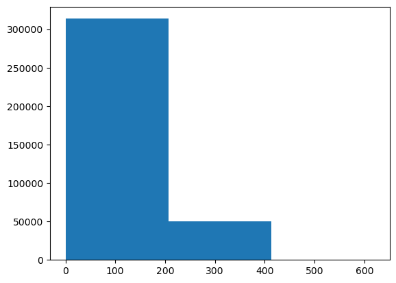

```python
plt.hist(final_df['Length'], bins=3)
plt.show()
```

```python
final_df['Airline'][final_df['Length']<200].value_counts()
```

```
WN    75941
DL    43872
OO    32965
AA    30246
MQ    26076
XE    22114
UA    16388
9E    13573
B6    11628
OH     9963
YV     9884
AS     6350
F9     5406
HA     3034
Name: Airline, dtype: int64
```

Airline For Short Distance Travel

```python
final_df['Airline'][final_df['Length']>400].value_counts()
```

```
UA    549
AA    304
DL    226
B6     83
AS     31
HA     14
Name: Airline, dtype: int64
```

Airline For Long Distance Travel

And Remaining Are For Medium Distance Travel

# D. Patterns in the departure times of long-duration flights

```python
final_df['Time'] [final_df['Length']>400]
```

```
46345     1045
46348     1045
46356     1045
46364     1045
46367     1045
          ...
315043    1416
315049    1416
315055    1416
315061    1416
315067    1416
Name: Time, Length: 1207, dtype: int64
```

```python
final_df['Length']>400
```

```
0         False
1         False
2         False
3         False
4         False
          ...
364272    False
364273    False
364274    False
364275    False
364276    False
Name: Length, Length: 364277, dtype: bool
```

# 4. visualization to represent of flights were delayed at large hubs compared to medium hubs

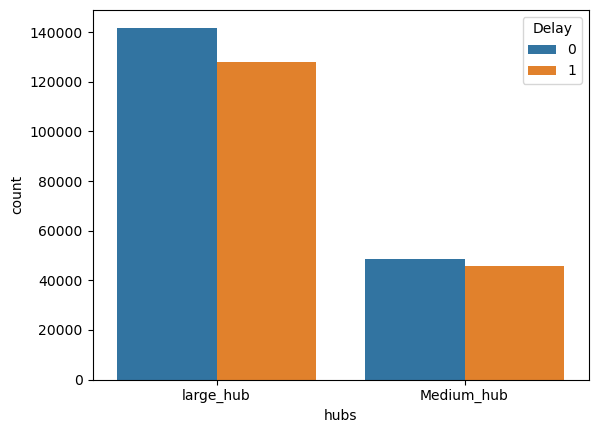

```python
sns.countplot(final_df['hubs'], hue= final_df['Delay'])
plt.show()
```

# 5. Use hypothesis testing strategies to discover:

a. If the airport's altitude has anything to do with flight delays for incoming and departing flights

```python
from scipy.stats import chi2_contingency
table = [final_df['latitude_deg'],final_df['Delay']]
stat, p, dof, expected = chi2_contingency(table)
print('stat=%.3f, p=%.3f' % (stat, p))
if p > 0.05:
    print('Probably independent')
else:
    print('Probably dependent')
```

```
stat=194730.438, p=1.000
Probably independent
```

b. If the number of runways at an airport affects flight delays

```python
from scipy.stats import chi2_contingency
table = [final_df['airport_ref'],final_df['Delay']]
stat, p, dof, expected = chi2_contingency(table)
print('stat=%.3f, p=%.3f' % (stat, p))
if p > 0.05:
    print('Probably independent')
else:
    print('Probably dependent')
```

```
stat=200241.469, p=1.000
Probably independent
```

c. If the duration of a flight (length) affects flight delays

```python
from scipy.stats import spearmanr
data1 = final_df['Length']
data2 = final_df['Delay']
stat, p = spearmanr(data1, data2)
print('stat=%.3f, p=%.3f' % (stat, p))
if p > 0.05:
    print('Probably independent')
else:
    print('Probably dependent')
```

```
stat=-0.002, p=0.203
Probably independent
```

# 6. Correlation Matrix

```python
predictor = final_df.drop(['Delay'], axis=1)
corr= predictor.corr()
corr
```

|  | Flight | DayOfWeek | Time | Length | latitude_deg | longitude_deg | elevation_ft | airport_ref | length_ft | width_ft | lighted | closed | Founded | traffic_Chg19_20 | traffic_Chg18_19 |
| --- | --- | --- | --- | --- | --- | --- | --- | --- | --- | --- | --- | --- | --- | --- | --- |
| Flight | 1.000000 | 0.003249 | 0.034959 | -0.311840 | 0.168127 | 0.061268 | 0.124437 | -0.042421 | 0.016064 | 0.010186 | 0.064012 | 0.029169 | 0.389930 | -0.048014 | 0.010379 |
| DayOfWeek | 0.003249 | 1.000000 | 0.002218 | 0.013059 | -0.010100 | -0.005075 | 0.000010 | 0.002675 | 0.004768 | 0.003414 | -0.004520 | -0.004811 | -0.005840 | -0.005420 | 0.005002 |
| Time | 0.034959 | 0.002218 | 1.000000 | -0.045729 | -0.024743 | -0.002804 | 0.039522 | -0.014048 | 0.029940 | 0.038049 | -0.001339 | -0.006927 | 0.033776 | -0.084557 | 0.070448 |
| Length | -0.311840 | 0.013059 | -0.045729 | 1.000000 | 0.028905 | 0.068559 | -0.070187 | -0.012986 | 0.083335 | 0.062138 | 0.029629 | -0.062091 | -0.318902 | -0.112389 | -0.009942 |
| latitude_deg | 0.168127 | -0.010100 | -0.024743 | 0.028905 | 1.000000 | 0.087885 | 0.208233 | -0.095324 | 0.004430 | -0.034404 | 0.205215 | 0.087013 | 0.042304 | -0.053065 | -0.114517 |
| longitude_deg | 0.061268 | -0.005075 | -0.002804 | 0.068559 | 0.087885 | 1.000000 | -0.208175 | -0.190519 | 0.114385 | 0.024904 | 0.325019 | -0.056677 | 0.107272 | -0.031525 | 0.027168 |
| elevation_ft | 0.124437 | 0.000010 | 0.039522 | -0.070187 | 0.208233 | -0.208175 | 1.000000 | 0.224565 | 0.225928 | -0.155231 | -0.141753 | -0.009500 | 0.009172 | -0.026185 | 0.366671 |
| airport_ref | -0.042421 | 0.002675 | -0.014048 | -0.012986 | -0.095324 | -0.190519 | 0.224565 | 1.000000 | 0.015333 | -0.027424 | -0.667705 | -0.020312 | -0.011249 | 0.175674 | -0.152696 |
| length_ft | 0.016064 | 0.004768 | 0.029940 | 0.083335 | 0.004430 | 0.114385 | 0.225928 | 0.015333 | 1.000000 | 0.211039 | 0.076685 | -0.226149 | 0.038781 | -0.181335 | 0.307367 |
| width_ft | 0.010186 | 0.003414 | 0.038049 | 0.062138 | -0.034404 | 0.024904 | -0.155231 | -0.027424 | 0.211039 | 1.000000 | 0.133766 | -0.277982 | -0.057439 | -0.167012 | 0.265583 |
| lighted | 0.064012 | -0.004520 | -0.001339 | 0.029629 | 0.205215 | 0.325019 | -0.141753 | -0.667705 | 0.076685 | 0.133766 | 1.000000 | -0.125378 | 0.043066 | -0.148283 | 0.098183 |
| closed | 0.029169 | -0.004811 | -0.006927 | -0.062091 | 0.087013 | -0.056677 | -0.009500 | -0.020312 | -0.226149 | -0.277982 | -0.125378 | 1.000000 | 0.098511 | 0.156152 | -0.079890 |
| Founded | 0.389930 | -0.005840 | 0.033776 | -0.318902 | 0.042304 | 0.107272 | 0.009172 | -0.011249 | 0.038781 | -0.057439 | 0.043066 | 0.098511 | 1.000000 | 0.165866 | -0.133330 |
| traffic_Chg19_20 | -0.048014 | -0.005420 | -0.084557 | -0.112389 | -0.053065 | -0.031525 | -0.026185 | 0.175674 | -0.181335 | -0.167012 | -0.148283 | 0.156152 | 0.165866 | 1.000000 | -0.466197 |
| traffic_Chg18_19 | 0.010379 | 0.005002 | 0.070448 | -0.009942 | -0.114517 | 0.027168 | 0.366671 | -0.152696 | 0.307367 | 0.265583 | 0.098183 | -0.079890 | -0.133330 | -0.466197 | 1.000000 |

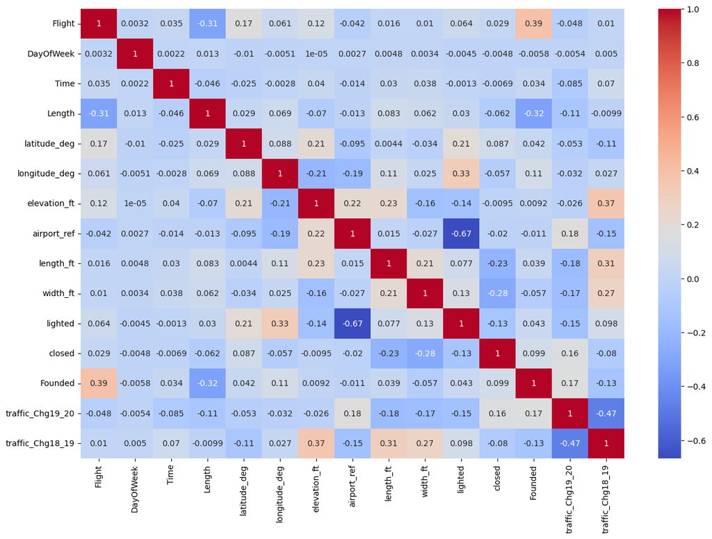

```python
plt.figure(figsize=(15,10))
sns.heatmap(corr, annot=True, cmap='coolwarm')
plt.show()
```

# Machine Learning

1. Use OneHotEncoder and OrdinalEncoder to deal with categorical variables

```python
# Before applying the one hot encodding or the label encoding first we check all feature data type.
final_df.info()
```

```
<class 'pandas.core.frame.DataFrame'>
Int64Index: 364277 entries, 0 to 364276
Data columns (total 21 columns):
 #   Column             Non-Null Count   Dtype
---  ------             --------------   -----
 0   Airline            364277 non-null  object
 1   Flight             364277 non-null  int64
 2   DayOfWeek          364277 non-null  int64
 3   Time               364277 non-null  int64
 4   Length             364277 non-null  int64
 5   Delay              364277 non-null  int64
 6   type               364277 non-null  object
 7   latitude_deg       364277 non-null  float64
 8   longitude_deg      364277 non-null  float64
 9   elevation_ft       364277 non-null  float64
 10  scheduled_service  364277 non-null  object
 11  home_link          293094 non-null  object
 12  airport_ref        364277 non-null  int64
 13  length_ft          364277 non-null  float64
 14  width_ft           364277 non-null  float64
 15  lighted            364277 non-null  int64
 16  closed             364277 non-null  int64
 17  Founded            364277 non-null  float64
 18  traffic_Chg19_20   364277 non-null  int64
 19  traffic_Chg18_19   364277 non-null  int64
 20  hubs               364277 non-null  object
dtypes: float64(6), int64(10), object(5)
memory usage: 61.1+ MB
```

```python
final_df['Airline'].value_counts()
```

```
WN    85067
DL    57720
AA    43261
OO    33843
UA    26535
MQ    26308
XE    22566
B6    15497
9E    13573
OH    10211
YV    10002
AS     9477
F9     6180
HA     4037
Name: Airline, dtype: int64
```

```python
final_df['type'].value_counts()
```

```
large_airport     342705
medium_airport     21572
Name: type, dtype: int64
```

```python
final_df['scheduled_service'].value_counts()
```

```
yes    364277
Name: scheduled_service, dtype: int64
```

```python
final_df['hubs'].value_counts()
```

```
large_hub     269953
Medium_hub     94324
Name: hubs, dtype: int64
```

```python
final_df = final_df.drop(['scheduled_service'], axis=1)
```

```python
# Now using the ordinal encoder.
from sklearn.preprocessing import LabelEncoder
le = LabelEncoder()
```

```python
final_df['Airline'] = le.fit_transform(final_df['Airline'])
final_df['type'] = le.fit_transform(final_df['type'])
final_df['hubs'] = le.fit_transform(final_df['hubs'])
```

```python
final_df.head()
```

|  | Airline | Flight | DayOfWeek | Time | Length | Delay | type | latitude_deg | longitude_deg | elevation_ft | home_link | airport_ref | length_ft | width_ft | lighted | closed | Founded | traffic_Chg19_20 | traffic_Chg18_19 | hubs |
| --- | --- | --- | --- | --- | --- | --- | --- | --- | --- | --- | --- | --- | --- | --- | --- | --- | --- | --- | --- | --- |
| 0 | 1 | 2466 | 3 | 20 | 195 | 1 | 0 | 37.618999 | -122.375 | 13.0 | http://www.flysfo.com/ | 3878 | 7500.0 | 200.0 | 1 | 0 | 1926.0 | -20034173 | -11487 | 1 |
| 1 | 1 | 526 | 3 | 360 | 215 | 0 | 0 | 37.618999 | -122.375 | 13.0 | http://www.flysfo.com/ | 3878 | 7500.0 | 200.0 | 1 | 0 | 1926.0 | -20034173 | -11487 | 1 |
| 2 | 1 | 552 | 3 | 360 | 315 | 1 | 0 | 37.618999 | -122.375 | 13.0 | http://www.flysfo.com/ | 3878 | 7500.0 | 200.0 | 1 | 0 | 1926.0 | -20034173 | -11487 | 1 |
| 3 | 1 | 810 | 3 | 385 | 255 | 0 | 0 | 37.618999 | -122.375 | 13.0 | http://www.flysfo.com/ | 3878 | 7500.0 | 200.0 | 1 | 0 | 1926.0 | -20034173 | -11487 | 1 |
| 4 | 1 | 24 | 3 | 425 | 325 | 1 | 0 | 37.618999 | -122.375 | 13.0 | http://www.flysfo.com/ | 3878 | 7500.0 | 200.0 | 1 | 0 | 1926.0 | -20034173 | -11487 | 1 |

1. Perform the following model building steps

# Logistic Regression

```python
# Lets first seperate the predictors and the output Variable.
x = final_df.drop(['Delay'], axis= 1)
y = final_df["Delay"]
```

```python
from sklearn import preprocessing
scaler = preprocessing.MinMaxScaler()
x = scaler.fit_transform(x)
```

[output not shown]

```python
# First Split the data into the training and testing set before performing the further operation.
from sklearn.model_selection import train_test_split
```

```python
x_train, x_test, y_train, y_test = train_test_split(x, y, train_size=0.9, random_state=10)
```

```python
# lets apply the logistic regression with the randomsearchcv hypermeter tunning.
from sklearn.linear_model import LogisticRegression
lr = LogisticRegression()
```

```python
from sklearn.model_selection import RandomizedSearchCV
```

```python
params = {"penalty": ["l1","l2"],
         'solver': ['newton-cg', 'liblinear']}

# Cross Validation
folds = 5

rscv = RandomizedSearchCV(estimator = lr,
                         param_distributions = params,
                         scoring = "accuracy",
                         verbose = 1,
                         cv= folds)
rscv.fit(x_train, y_train)
```

```
Fitting 5 folds for each of 4 candidates, totalling 20 fits
```

[output not shown]

```python
print(rscv.best_params_)
print(rscv.best_score_)
```

```
{'solver': 'newton-cg', 'penalty': 'l1'}
nan
```

```python
lr = LogisticRegression(penalty= 'l2', solver= 'newton-cg')
lr.fit(x_train,y_train).score(x_train,y_train)
```

[output not shown]